# Feature Engineering and Principal Components Analysis in R

If a house/property is on the opposite side of a given variable this indicates that the house has a low value for this variable.

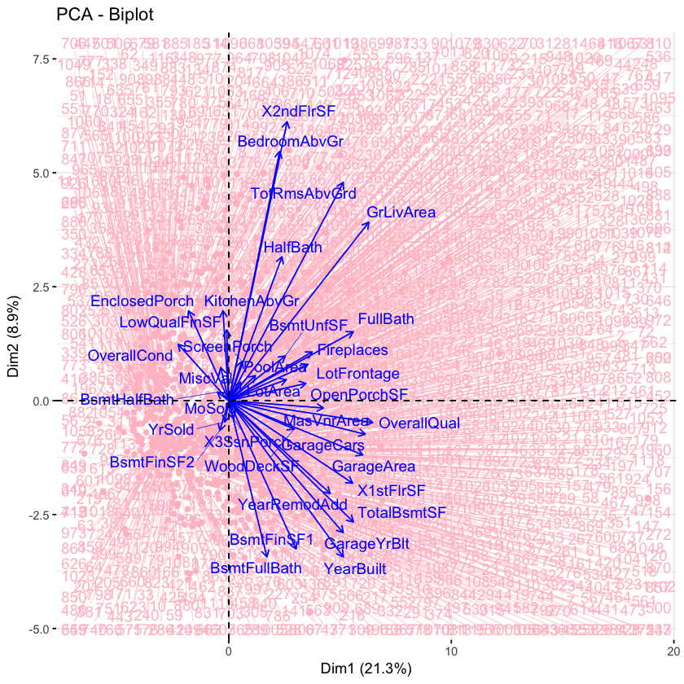

```r
fviz_pca_biplot(prin_comp, repel = TRUE,
                col.var = "blue", # variable color
                col.ind = "pink"  # property color
                )
```

The final components are chosen with the Eigenvalue > 1 rule because we want components that capture as much variation as a single feature. The final components meet underlying model assumptions by providing components with correlations of 0.

```r
#we will go with 11 components
#based on the eigenvalue > 1 rule and scree plot
eig.val <- get_eigenvalue(prin_comp)
eig.val
```

|  | eigenvalue | variance.percent | cumulative.variance.percent |
| --- | --- | --- | --- |
| Dim.1 | 7.459066e+00 | 2.131162e+01 | 21.31162 |
| Dim.2 | 3.101910e+00 | 8.862599e+00 | 30.17422 |
| Dim.3 | 2.623779e+00 | 7.496512e+00 | 37.67073 |
| Dim.4 | 1.888627e+00 | 5.396077e+00 | 43.06681 |
| Dim.5 | 1.450215e+00 | 4.143472e+00 | 47.21028 |
| Dim.6 | 1.214765e+00 | 3.470758e+00 | 50.68104 |
| Dim.7 | 1.199652e+00 | 3.427578e+00 | 54.10861 |
| Dim.8 | 1.134049e+00 | 3.240140e+00 | 57.34875 |
| Dim.9 | 1.093641e+00 | 3.124689e+00 | 60.47344 |
| Dim.10 | 1.084856e+00 | 3.099590e+00 | 63.57303 |
| Dim.11 | 1.057132e+00 | 3.020377e+00 | 66.59341 |
| Dim.12 | 9.966486e-01 | 2.847567e+00 | 69.44098 |
| Dim.13 | 9.736635e-01 | 2.781896e+00 | 72.22287 |
| Dim.14 | 8.997983e-01 | 2.570852e+00 | 74.79372 |
| Dim.15 | 8.688270e-01 | 2.482363e+00 | 77.27609 |
| Dim.16 | 8.405828e-01 | 2.401665e+00 | 79.67775 |
| Dim.17 | 7.897619e-01 | 2.256463e+00 | 81.93422 |
| Dim.18 | 7.545631e-01 | 2.155894e+00 | 84.09011 |
| Dim.19 | 7.043127e-01 | 2.012322e+00 | 86.10243 |
| Dim.20 | 6.749913e-01 | 1.928547e+00 | 88.03098 |
| Dim.21 | 6.344968e-01 | 1.812848e+00 | 89.84383 |
| Dim.22 | 5.867408e-01 | 1.676402e+00 | 91.52023 |
| Dim.23 | 5.278446e-01 | 1.508127e+00 | 93.02836 |
| Dim.24 | 4.695727e-01 | 1.341636e+00 | 94.36999 |
| Dim.25 | 3.791495e-01 | 1.083284e+00 | 95.45328 |
| Dim.26 | 3.207987e-01 | 9.165678e-01 | 96.36984 |
| Dim.27 | 2.682981e-01 | 7.665659e-01 | 97.13641 |
| Dim.28 | 2.504491e-01 | 7.155690e-01 | 97.85198 |
| Dim.29 | 2.075602e-01 | 5.930292e-01 | 98.44501 |
| Dim.30 | 1.760904e-01 | 5.031155e-01 | 98.94812 |
| Dim.31 | 1.424000e-01 | 4.068571e-01 | 99.35498 |
| Dim.32 | 1.219365e-01 | 3.483901e-01 | 99.70337 |
| Dim.33 | 1.038202e-01 | 2.966290e-01 | 100.00000 |
| Dim.34 | 1.471041e-30 | 4.202975e-30 | 100.00000 |
| Dim.35 | 2.206858e-31 | 6.305309e-31 | 100.00000 |

Similarly, the scree plot rule of thumb is to pick the components leading up to the "elbow" of the plot. The compnents after the "elbow" are assumed to not contain much additional variance.

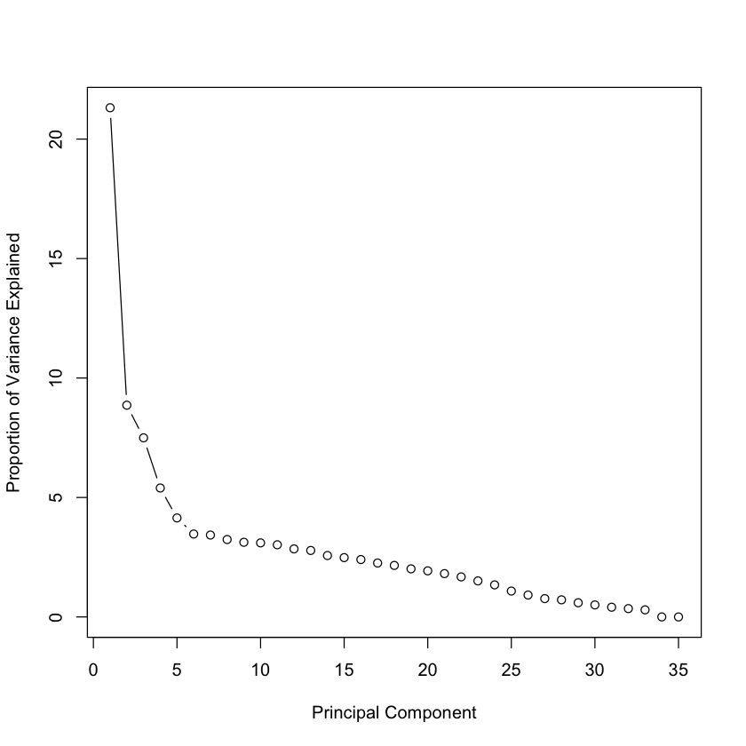

```r
#scree plot
plot(eig.val[,2], xlab = "Principal Component",
             ylab = "Proportion of Variance Explained",
             type = "b")
```

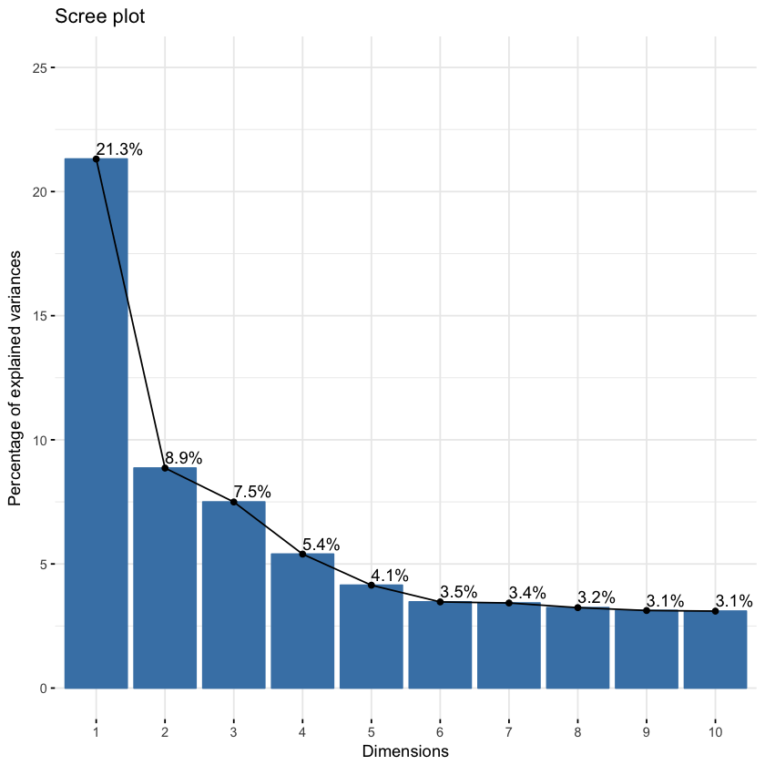

```r
fviz_eig(prin_comp, addlabels = TRUE, ylim = c(0, 25))
```

```r
var <- get_pca_var(prin_comp)
var
```

```
Principal Component Analysis Results for variables
 ===================================================
  Name       Description
1 "$coord"   "Coordinates for the variables"
2 "$cor"     "Correlations between variables and dimensions"
3 "$cos2"    "Cos2 for the variables"
4 "$contrib" "contributions of the variables"
```

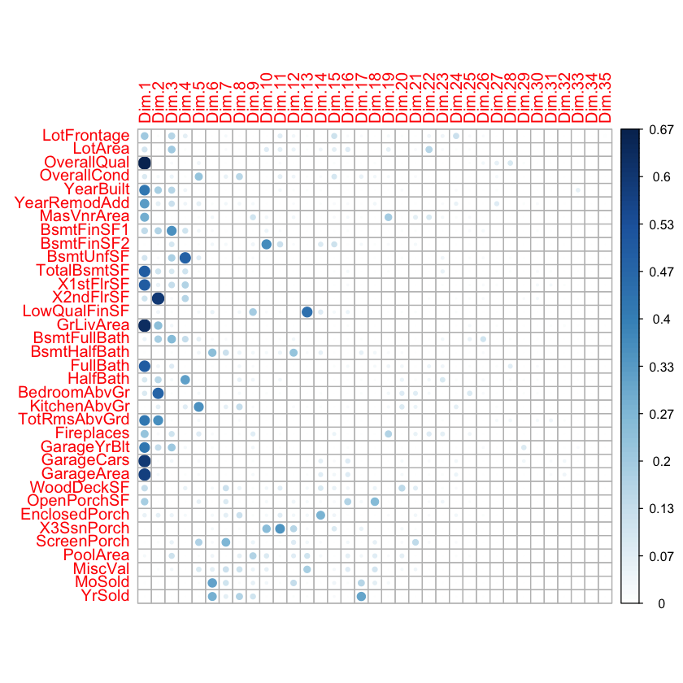

```r
corrplot(var$cos2, is.corr=FALSE)
```

**Sources:**

- https://www.r-bloggers.com/principal-component-analysis-in-r/
- Thinkful.com curriculum
- Introduction to Data Mining by Michael Steinbach, Pang-Ning Tan, and Vipin Kumar
- http://www.unh.edu/halelab/BIOL933/Labs/Lab6.pdf
- https://www.analyticsvidhya.com/blog/2016/03/practical-guide-principal-component-analysis-python/
- http://www.sthda.com/english/articles/31-principal-component-methods-in-r-practical-guide/112-pca-principal-component-analysis-essentials/